# PREGUNTA 1

# PREGUNTA 3

Con los datos de Decathlon (sin puntaje y rango) calcular las estadisticas univariadas de las diez especialidades para las dos clases Olimpiadas y Decastar.¿Cual es la razon de correlacion por cada especialidad? Cual es la que distingue mas los dos grupos?

**Solucion**

De los datos Decathlon, se hara las estadisticas univariadas por diciplina(variable cuantitativa) y se presentara la tabla respectiva.

```r
#numero de variables
n=length(deca)-3

for (i in c(1:n)){
  #titulo de la tabla
  cat("\n\n")
  print(noquote(paste0(prefix="Estadistica Univariada de la variable ",colnames(deca)[i])))

  #Total de observaciones de la variable i
  n_t = length(deca[,i])

  #Media de las observaciones de la variable i
  m_t = mean(deca[,i])

  #Varianza de las observaciones de la variable i
  v_t = var(deca[,i])*(n_t-1)/n_t

  #Desviacon Standar de las observaciones de la variable i
  s_t = sqrt(v_t)

  #Coeficiente de variacion de las observaciones de la variable i
  cvt = s_t/m_t

  #Agrupamiento de las estadisticas totales
  total=rbind(n_t,m_t,v_t,s_t,cvt)

  #Estadisticas por varible categorica (Variable 13)
  n_unit=table(deca[,13])

  #MEdia por categorica (Variable 13)
  mean=tapply(deca[,i],deca[,13],mean)

  #Varianza por categorica (Variable 5)
  var=tapply(deca[,i],deca[,13],var)
  var=var*(n_unit-i)/n_unit

  #Desviacion Standar por categorica (Variable 13)
  stdev=sqrt(var)
  cv=stdev/mean

  #Agrupamiento de las estadisticas parciales por variable categorica
  brk=rbind(n_unit,mean,var,stdev,cv)

  #Agrupamiento de la estadisticas por categoria (Var 13) contra la estadistica global(var i)
  brtot=cbind(brk,total)
  colnames(brtot) = c(colnames(brk),"total")
  print(brtot)

  e2 = sum(n_unit*(mean-m_t)^2) / (n_t*v_t)
  e=sqrt(e2)
  cat("Razon de correlacion(e): ",e)
}
```

```
##
##
## [1] Estadistica Univariada de la variable X100m
##           Decastar    OlympicG       total
## n_unit 13.00000000 28.00000000 41.00000000
## mean   11.17538462 10.91571429 10.99804878
## var     0.05596331  0.05146735  0.06749375
## stdev   0.23656566  0.22686416  0.25979560
## cv      0.02116846  0.02078326  0.02362197
## Razon de correlacion(e):  0.4651118
##
## [1] Estadistica Univariada de la variable Long.jump
##           Decastar    OlympicG       total
## n_unit 13.00000000 28.00000000 41.00000000
## mean    7.24769231  7.26571429  7.26000000
## var     0.06060089  0.10806115  0.09766829
## stdev   0.24617248  0.32872656  0.31251927
## cv      0.03396564  0.04524353  0.04304673
## Razon de correlacion(e):  0.02683444
##
## [1] Estadistica Univariada de la variable Shot.put
##           Decastar    OlympicG       total
## n_unit 13.00000000 28.00000000 41.00000000
## mean   14.15846154 14.62500000 14.47707317
## var     0.35004931  0.65456680  0.66310363
## stdev   0.59164965  0.80905303  0.81431175
## cv      0.04178771  0.05531987  0.05624837
## Razon de correlacion(e):  0.2666021
##
## [1] Estadistica Univariada de la variable High.jump
##            Decastar     OlympicG        total
## n_unit 13.000000000 28.000000000 41.000000000
## mean    1.977692308  1.976428571  1.976829268
## var     0.005655621  0.006934694  0.007719215
## stdev   0.075203865  0.083274809  0.087859062
## cv      0.038026069  0.042133984  0.044444436
## Razon de correlacion(e):  0.006693245
##
## [1] Estadistica Univariada de la variable X400m
##           Decastar    OlympicG       total
```

[output cut: 36 more lines]

```
## n_unit 13.00000000 28.0000000 41.00000000
## mean   56.95461538 58.9489286 58.31658537
## var     5.84928521 16.8008020 22.72994444
## stdev   2.41852955  4.0988781  4.76759315
## cv      0.04246415  0.0695327  0.08175364
## Razon de correlacion(e):  0.194653
##
## [1] Estadistica Univariada de la variable X1500m
##            Decastar    OlympicG        total
## n_unit  13.00000000  28.0000000  41.00000000
## mean   282.20000000 277.5507143 279.02487805
## var     34.57153846  82.4038425 132.94117133
## stdev    5.87975667   9.0776562  11.53001177
## cv       0.02083542   0.0327063   0.04132252
## Razon de correlacion(e):  0.1876391
```

Observe que para valores que se acerca a $e=1$, la dispersión de la variable global se debe únicamente a la dispersión entre las categorías y en absoluto debido a la dispersión dentro de las categorías individuales. Para nuestro caso quien distigue mas los dos grupos categoricos es la variable X100m, con una razon de correlacion de $e=0.4651118$

# PREGUNTA 4

¿Como se comparte la inercia total (suma de las inercias de cada variable) entre las dos clases y dentro de ellas?

**Solucion**

Primero se hara el calculo de la inercia total:

```r
#eliminando columnas
deca<-subset(deca,select=-Rank)
deca<-subset(deca,select=-Points)

#numero de variables
n=length(deca)-1

#numero de observaciones
m=dim(deca)[1]

#Estadisticas por varible categorica (Variable 13)
n_unit=table(deca[,n])

#calculo del centroide total
G<- matrix(nrow = 1, ncol = n)
for (i in c(1:n)){
  G[1,i]<-mean(deca[,i])
}

#matriz llena con el promedio en todas sus filas
mat<-G
for(i in 1:(m-1)){
  mat<-rbind(mat,G)
}

#calculo de las inercias
I<-0
dif<-deca[,1:10]-mat
for (i in 1:m){
  #deca[i,12]=sqrt(sum(dif[i,]*dif[i,]))
  I=I+sum(dif[i,]*dif[i,])
}
cat("SST=",I)
```

```
## SST= 6938.397
```

Ahora se calculara la inercias por grupo, para lo cual se separara el dataframe por clases y cada clase se calculara sus inercias correspondientes.

```r
#separacion de la tabla deca por clases
df<-split(deca,deca$Competition)
```

Para el calculo de la Inercia de la clase Decastar, se tiene:

```r
#numero de variables
n=length(df$Decastar)-1;

#numero de observaciones
m1=dim(df$Decastar)[1];

#cALCULO DEL CENTROIDE
G1<- matrix(nrow = 1, ncol = n)
for (i in c(1:n)){
  G1[1,i]<-mean(df$Decastar[,i])
}
cat("Centroide de Decastar(G1):\n",G1)
```

```
## Centroide de Decastar(G1):
##  11.17538 7.247692 14.15846 1.977692 49.63 14.71846 44.21769 4.827692 56.95462 282.2
```

```r
#matriz llena todas sus filas con el centroide de la clase 1
mat<-G1
for(i in 1:(m1-1)){
  mat<-rbind(mat,G1)
}

#calculo de las inercias por grupo 1.
I1<-0
dif<-df$Decastar[,1:10]-mat
for (i in 1:m1){
  I1=I1+sum(dif[i,]*dif[i,])
}
cat("SSD1=",I1)
```

```
## SSD1= 2209.095
```

Para el calculo de la Inercia de la clase OlympicG, se tiene:

```r
#numero de variables
n=length(df$OlympicG)-1

#numero de observaciones
m2=dim(df$OlympicG)[1]

#cALCULO DEL CENTROIDE
G2<- matrix(nrow = 1, ncol = n)
for (i in c(1:n)){
  G2[1,i]<-mean(df$OlympicG[,i])
}
cat("Centroide de OlympicG (G2):\n",G2)
```

```
## Centroide de OlympicG (G2):
##  10.91571 7.265714 14.625 1.976429 49.61 14.55357 44.37571 4.732143 58.94893 277.5507
```

```r
#matriz llena todas sus filas con el centroide de la clase 1
mat<-G2
for(i in 1:(m2-1)){
  mat<-rbind(mat,G2)
}

#calculo de las inercias por grupo 2
I2<-0
dif<-df$OlympicG[,1:10]-mat
for (i in 1:m2){
  I2=I2+sum(dif[i,]*dif[i,])
}
cat("SSD2=",I2)
```

```
## SSD2= 4499.003
```

Se procedera calcular la Inercia entre clases (SSC):

```r
SSC<-m1*sum((G1-G)*(G1-G))+m2*sum((G2-G)*(G2-G))
```

*Resumen de los calculos*

```r
for( i in 1:1){
  cat("######################   RESUMEN DE CALCULOS   #######################\n\n")
  cat("Centroide total de los datos(G):\n",G)
  cat("\nNumero observaciones totales(n):",m)
  cat("\nInercia total (SST):",I)

  cat("\n\nCentroide de la clase Decastar(G1):\n",G1)
  cat("\nNumero observaciones por la clase Decastar(n1):",m1)
  cat("\nInercia dentro de clase Decastar(SSD1):",I1)

  cat("\n\nCentroide de la clase OlympicG(G2):\n",G2)
  cat("\nNumero observaciones por la clase OlympicG(n2):",m2)
  cat("\nInercia dentro de clase OlympicG(SSD2):",I2)

  cat("\n\nInercia dentro de clases(SSD=SSD1+SSD2):",I1+I2)
  cat("\n\nInercia entres clases(SSC):",SSC)
  cat("\n\nCalculo de SSD+SSC:",SSC+I1+I2)
}
```

```
## ######################   RESUMEN DE CALCULOS   #######################
##
## Centroide total de los datos(G):
##  10.99805 7.26 14.47707 1.976829 49.61634 14.60585 44.32561 4.762439 58.31659 279.0249
## Numero observaciones totales(n): 41
## Inercia total (SST): 6938.397
##
## Centroide de la clase Decastar(G1):
##  11.17538 7.247692 14.15846 1.977692 49.63 14.71846 44.21769 4.827692 56.95462 282.2
## Numero observaciones por la clase Decastar(n1): 13
## Inercia dentro de clase Decastar(SSD1): 2209.095
##
## Centroide de la clase OlympicG(G2):
##  10.91571 7.265714 14.625 1.976429 49.61 14.55357 44.37571 4.732143 58.94893 277.5507
## Numero observaciones por la clase OlympicG(n2): 28
## Inercia dentro de clase OlympicG(SSD2): 4499.003
##
## Inercia dentro de clases(SSD=SSD1+SSD2): 6708.098
##
## Inercia entres clases(SSC): 230.2988
##
## Calculo de SSD+SSC: 6938.397
```

**Comentarios**

Se observa que SSD+SSC=SST, lo cual nos indica que los calculos estan correctos. Una inercia dentro de las clases(SSD) alta indica que hay una considerable variabilidad dentro de cada clase o grupo en relación con la variable que estás analizando. Esto sugiere que las observaciones dentro de cada clase pueden ser bastante heterogéneas, a pesar de que pertenecen a la misma categoría.

# PREGUNTA 5

Calcular tambien la matriz de correlacion global y relativa a las dos clase. ¿Le parece muy combinada?

**Solucion**

Primero se calculara la matrix de correlacion Global de las variables Decathlon sin hacer la distincion de las dos clases.Vemos que las variable con mayor correlacion son:

```r
#Calculo de correlacion de toda la tabla, cruzando variables
cor(deca[,1:10])
```

```
##                    X100m   Long.jump    Shot.put   High.jump        X400m
## X100m         1.00000000 -0.59867767 -0.35648227 -0.24625292  0.520298155
## Long.jump    -0.59867767  1.00000000  0.18330436  0.29464444 -0.602062618
## Shot.put     -0.35648227  0.18330436  1.00000000  0.48921153 -0.138432919
## High.jump    -0.24625292  0.29464444  0.48921153  1.00000000 -0.187956928
## X400m         0.52029815 -0.60206262 -0.13843292 -0.18795693  1.000000000
## X110m.hurdle  0.57988893 -0.50541009 -0.25161571 -0.28328909  0.547987756
## Discus       -0.22170757  0.19431009  0.61576810  0.36921834 -0.117879365
## Pole.vault   -0.08253683  0.20401411  0.06118185 -0.15618074 -0.079292469
## Javeline     -0.15774645  0.11975893  0.37495551  0.17188009  0.004232096
## X1500m       -0.06054645 -0.03368613  0.11580306 -0.04490252  0.408106432
##              X110m.hurdle     Discus   Pole.vault     Javeline      X1500m
## X100m         0.579888931 -0.2217076 -0.082536834 -0.157746452 -0.06054645
## Long.jump    -0.505410086  0.1943101  0.204014112  0.119758933 -0.03368613
## Shot.put     -0.251615714  0.6157681  0.061181853  0.374955509  0.11580306
## High.jump    -0.283289090  0.3692183 -0.156180742  0.171880092 -0.04490252
## X400m         0.547987756 -0.1178794 -0.079292469  0.004232096  0.40810643
## X110m.hurdle  1.000000000 -0.3262010 -0.002703885  0.008743251  0.03754024
## Discus       -0.326200961  1.0000000 -0.150072400  0.157889799  0.25817510
## Pole.vault   -0.002703885 -0.1500724  1.000000000 -0.030000603  0.24744778
## Javeline      0.008743251  0.1578898 -0.030000603  1.000000000 -0.18039313
## X1500m        0.037540240  0.2581751  0.247447780 -0.180393128  1.00000000
```

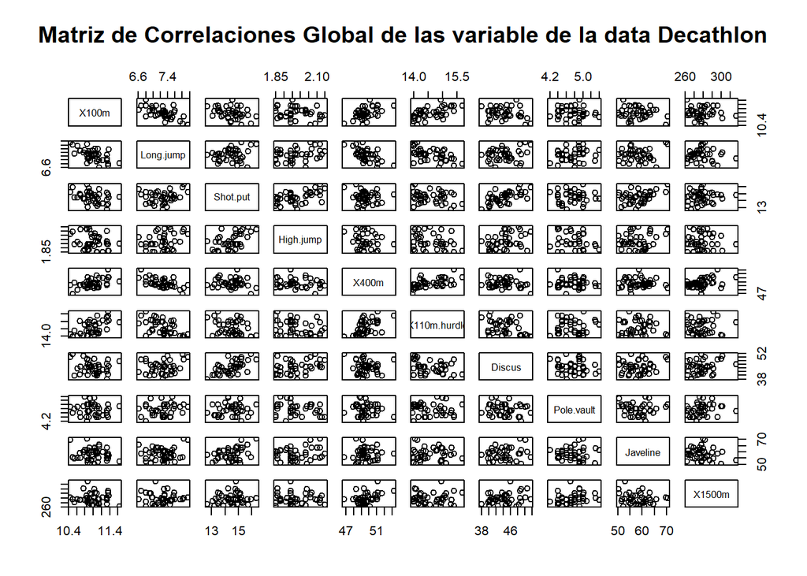

```r
#Matriz de Correlaciones total
plot(deca[,1:10], main="Matriz de Correlaciones Global de las variable de la data Decathlon")
```

Ahora se calculara la matrix de correlacion por variable por clases. Se inicia separando el dataframe ses segun las clases Decastar y OlympicG, con el siguiente codigo:

```r
#separacion de la tabla deca por clases
df<-split(deca,deca$Competition)
```

Ahora se calculara la matrix de correlacion por la clase Decastar:

```r
#matriz de correlacion para la clase Decastar
cor(df$Decastar[,1:10])
```

```
##                    X100m   Long.jump    Shot.put   High.jump       X400m
## X100m         1.00000000 -0.57065979 -0.02106781 -0.22406593  0.46704516
## Long.jump    -0.57065979  1.00000000  0.13688983  0.15686221 -0.32608786
## Shot.put     -0.02106781  0.13688983  1.00000000  0.22750226  0.09055474
## High.jump    -0.22406593  0.15686221  0.22750226  1.00000000 -0.25593801
## X400m         0.46704516 -0.32608786  0.09055474 -0.25593801  1.00000000
## X110m.hurdle  0.63859914 -0.46830241 -0.16867025 -0.22084457  0.69990139
## Discus       -0.24970224  0.05813601  0.57628265  0.07438561 -0.05147161
## Pole.vault    0.01146088 -0.03335974  0.39459529 -0.46407203  0.04065305
## Javeline     -0.23677658  0.19270420  0.20757999  0.10641649  0.22472755
## X1500m       -0.61609866  0.28343776  0.30206769 -0.13717271  0.03948944
##              X110m.hurdle      Discus  Pole.vault    Javeline      X1500m
## X100m           0.6385991 -0.24970224  0.01146088 -0.23677658 -0.61609866
## Long.jump      -0.4683024  0.05813601 -0.03335974  0.19270420  0.28343776
## Shot.put       -0.1686702  0.57628265  0.39459529  0.20757999  0.30206769
## High.jump      -0.2208446  0.07438561 -0.46407203  0.10641649 -0.13717271
## X400m           0.6999014 -0.05147161  0.04065305  0.22472755  0.03948944
## X110m.hurdle    1.0000000 -0.51358747  0.23167006  0.30521009 -0.29246512
## Discus         -0.5135875  1.00000000 -0.06837298 -0.06654772  0.35488724
## Pole.vault      0.2316701 -0.06837298  1.00000000  0.20281797  0.33514773
## Javeline        0.3052101 -0.06654772  0.20281797  1.00000000  0.09104917
## X1500m         -0.2924651  0.35488724  0.33514773  0.09104917  1.00000000
```

Se observa de matriz de correlacion, la relacion mas alta y la menor:

- X400m - X110.hurdle, r=0.6999014
- X1500m - X100m, r=-0.61609866

Ahora se calculara la matrix de correlacion por la clase OlympicG:

```r
#matriz de correlacion para la clase OlympicG
cor(df$OlympicG[,1:10])
```

```
##                    X100m   Long.jump    Shot.put    High.jump       X400m
## X100m         1.00000000 -0.70496966 -0.36969566 -0.309283792  0.63478518
## Long.jump    -0.70496966  1.00000000  0.19545125  0.345662087 -0.67111115
## Shot.put     -0.36969566  0.19545125  1.00000000  0.612582295 -0.19930019
## High.jump    -0.30928379  0.34566209  0.61258229  1.000000000 -0.16915905
## X400m         0.63478518 -0.67111115 -0.19930019 -0.169159053  1.00000000
## X110m.hurdle  0.54255793 -0.53816329 -0.24506987 -0.325957691  0.51988045
## Discus       -0.23331691  0.24990923  0.66577435  0.516963291 -0.14418633
## Pole.vault   -0.26045206  0.28507937  0.02369214 -0.042382049 -0.11542821
## Javeline     -0.01168981  0.09379205  0.38334308  0.204481236 -0.05465387
## X1500m        0.05843441 -0.14742605  0.12954382 -0.003496111  0.55122370
##              X110m.hurdle     Discus  Pole.vault    Javeline       X1500m
## X100m          0.54255793 -0.2333169 -0.26045206 -0.01168981  0.058434406
## Long.jump     -0.53816329  0.2499092  0.28507937  0.09379205 -0.147426053
## Shot.put      -0.24506987  0.6657743  0.02369214  0.38334308  0.129543822
## High.jump     -0.32595769  0.5169633 -0.04238205  0.20448124 -0.003496111
## X400m          0.51988045 -0.1441863 -0.11542821 -0.05465387  0.551223700
## X110m.hurdle   1.00000000 -0.2168722 -0.15097483 -0.07981966  0.179045379
## Discus        -0.21687217  1.0000000 -0.18421149  0.25485350  0.220171580
## Pole.vault    -0.15097483 -0.1842115  1.00000000 -0.06610479  0.179471438
## Javeline      -0.07981966  0.2548535 -0.06610479  1.00000000 -0.251505647
## X1500m         0.17904538  0.2201716  0.17947144 -0.25150565  1.000000000
```

**Comentario**

# PREGUNTA 6

Repetir los pasos 4 y 5 para los datos Iris considerando las tres especies.

**Solucion**

Para este apartado, se hara una funcion en el cual se ingresara el dataframe al cual se quiere hallar su inercia total. La estructura del dataframe es que en la ultima variable este la variable cualitativa, el cual cual se excluira para el analasis.

```r
Inercia<-function(df,nr){
    #creacion de la lista vacia para los resultados
    res<-list()

    #numero de variables
    n<-length(df)-nr

    #numero de observaciones
    m<-dim(df)[1]
    res$m<-m

    #calculo del centroide del dateframe
    G<- matrix(nrow = 1, ncol = n)
    for (i in c(1:n)){
      G[1,i]<-mean(df[,i])
    }
    res$centroide<-G

    #matriz llena con el promedio en todas sus filas
    mat<-G
    for(i in 1:(m-1)){
      mat<-rbind(mat,G)
    }

    #calculo de la inercia
    I<-0
    dif<-df[,1:n]-mat
    for (i in 1:m){
      I=I+sum(dif[i,]*dif[i,])
      #cat("\n",i," - ",sum(dif[i,]*dif[i,]))
    }
    #print(I)
    res$inercia<-I
    res
}
```

```r
# Verificar la estructura de los datos
str(iris)
```

```
## 'data.frame':    150 obs. of  5 variables:
##  $ Sepal.length: num  5.1 4.9 4.7 4.6 5 5.4 4.6 5 4.4 4.9 ...
##  $ Sepal.width : num  3.5 3 3.2 3.1 3.6 3.9 3.4 3.4 2.9 3.1 ...
##  $ Petal.length: num  1.4 1.4 1.3 1.5 1.4 1.7 1.4 1.5 1.4 1.5 ...
##  $ Petal.width : num  0.2 0.2 0.2 0.2 0.2 0.4 0.3 0.2 0.2 0.1 ...
##  $ Species     : chr  "setosa" "setosa" "setosa" "setosa" ...
```

```r
# Visualizar los primeros registros de los datos sin modificar
head(iris,n=10)
```

|  | Sepal.length | Sepal.width | Petal.length | Petal.width | Species |
| --- | --- | --- | --- | --- | --- |
| 1 | 5.1 | 3.5 | 1.4 | 0.2 | setosa |
| 2 | 4.9 | 3.0 | 1.4 | 0.2 | setosa |
| 3 | 4.7 | 3.2 | 1.3 | 0.2 | setosa |
| 4 | 4.6 | 3.1 | 1.5 | 0.2 | setosa |
| 5 | 5.0 | 3.6 | 1.4 | 0.2 | setosa |
| 6 | 5.4 | 3.9 | 1.7 | 0.4 | setosa |
| 7 | 4.6 | 3.4 | 1.4 | 0.3 | setosa |
| 8 | 5.0 | 3.4 | 1.5 | 0.2 | setosa |
| 9 | 4.4 | 2.9 | 1.4 | 0.2 | setosa |
| 10 | 4.9 | 3.1 | 1.5 | 0.1 | setosa |

Ahora se separara el dataframe por clases. Los cuales se usaran luego con la funcion que calcula las inercia.

```r
#separacion de la tabla deca por clases
dfs<-split(iris,iris$Species)
```

Se usara el tema de la separacion del dataframe por clases y cada clase se calculara su inercia.

```r
#calculo de las inercias por clases
I_tot<-Inercia(iris,1)
I_1<-Inercia(dfs$setosa,1)
I_2<-Inercia(dfs$versicolor,1)
I_3<-Inercia(dfs$virginica,1)

for(i in (1:1)){
    cat("######################   RESUMEN DE CALCULOS   #######################\n\n")

    cat("Centroide total de los datos(G):\n",I_tot$centroide)
    cat("\nNumero observaciones totales(n):",I_tot$m)
    cat("\nInercia total (SST):",I_tot$inercia)

    cat("\n\nCentroide de la clase setosa(G1):\n",I_1$centroide)
    cat("\nNumero observaciones por la clase setosa(n1):",I_1$m)
    cat("\nInercia dentro de clase setosa(SSD1):",I_1$inercia)

    cat("\n\nCentroide de la clase versicolor(G2):\n",I_2$centroide)
    cat("\nNumero observaciones por la clase versicolor:",I_2$m)
    cat("\nInercia dentro de clase versicolor(SSD2):",I_2$inercia)

    cat("\n\nCentroide de la clase virginica(G3):\n",I_3$centroide)
    cat("\nNumero observaciones por la clase virginica:",I_3$m)
    cat("\nInercia dentro de clase virginica(SSD2):",I_3$inercia)

    cat("\n\nSSC:",I_1$m*sum((I_1$centroide-I_tot$centroide)*(I_1$centroide-I_tot$centroide))
      +I_2$m*sum((I_2$centroide-I_tot$centroide)*(I_2$centroide-I_tot$centroide))
      +I_3$m*sum((I_3$centroide-I_tot$centroide)*(I_3$centroide-I_tot$centroide)))
}
```

```
## ######################   RESUMEN DE CALCULOS   #######################
##
## Centroide total de los datos(G):
##  5.843333 3.057333 3.758 1.199333
## Numero observaciones totales(n): 150
## Inercia total (SST): 681.3706
##
## Centroide de la clase setosa(G1):
##  5.006 3.428 1.462 0.246
## Numero observaciones por la clase setosa(n1): 50
## Inercia dentro de clase setosa(SSD1): 15.151
##
## Centroide de la clase versicolor(G2):
##  5.936 2.77 4.26 1.326
## Numero observaciones por la clase versicolor: 50
## Inercia dentro de clase versicolor(SSD2): 30.6164
##
## Centroide de la clase virginica(G3):
##  6.588 2.974 5.552 2.026
## Numero observaciones por la clase virginica: 50
## Inercia dentro de clase virginica(SSD2): 43.53
##
## SSC: 592.0732
```

Se calculo *SSD* de la siguiente forma:

$$SSD=SSD1+SSD2+SSD3$$

```r
cat("SSD=SSD1+SSD2+SSD3=",I_1$inercia+I_2$inercia+I_3$inercia)
```

```
## SSD=SSD1+SSD2+SSD3= 89.2974
```

**Comentario**